# Beer Me Methodology

In the “Beer Me” analysis, several steps were performed before reaching the end outputs on the “Beer Comparisons” tab. At a high level here was the process:

1. Scrape the data from MolsonCoors, which can be found here: [molsoncoors.com](https://www.molsoncoors.com/sites/molsonco/files/Combined%20Website%20Update%2006112020_0.pdf) - This data was *messy* - as it was free text in a PDF - The scraping process was not as automated as I had hoped for, but it was certainly faster than manual copying and pasting
2. Cleaning the data
   - Some basic EDA and feature selection
   - Removed variables with zero or low variance
   - Combined ingredients that were similar
   - Created dummy-variables from the ingredients
   - The end result was a 222x186 data set
3. Partitioning Around Medoids (PAM) cluster algorithm
   - Unsupervised algorithm similar to k-means
   - Added cluster labels to the data set
4. Uniform Manifold Approximation and Projection (UMAP)
   - Dimensionality reduction technique
   - Very good at maintaining local and global structure of the data
5. Nearest Neighbors
   - Extract nearest neighbors for each beer
   - These neighbors are the recommendations

Parts 1 and 2 are not important to the methodology used in the application, so I will focus mainly parts 3,4, and 5.

# Libraries & Data

The following packages are needed.

```r
library(tidyverse)
library(stringr)
library(ggtext)
library(tidyr)
library(plotly)
library(StatMatch)
library(cluster)
library(uwot)
library(kableExtra)
library(formattable)
```

```r
beer_full <- beer_data %>%
  select(!c("Calories_from_fat","Cholesterol_mg","Fat_grams","Saturated_fat_grams","Trans_fat_grams","Fiber_grams"))
```

# Partitioning around Medoids

Partition around medics (PAM) is an algorithm that is intended to find objects (medoids) that are centrally located in clusters. The goal of the algorithm is to minimize the average dissimilarity of objects to their closest selected object.

I used the PAM clustering algorithm on the full beer data set. Before I ran the model, I had to create a distance matrix form the data. The distance matrix has pairwise distances for each data point. I used the gower distance, because I had a mix of numerical and categorical variables.

```r
# Gower Dist
cluster_data_input <- beer_full %>% select(!c("Brand","Brand_Style","Ingredients")) # Don't include raw text columns
cluster_dist_input <- dist(cluster_data_input, method = "gower")
```

For the PAM cluster, I chose k = 10 (clusters) based on the [Silhouette method](https://en.wikipedia.org/wiki/Silhouette_(clustering), which is a measure of how similar objects are to their cluster label. Values for k = 5:20 produced similar silhouette scores, but I chose 10 based on some domain knowledge of the beer data set.

```r
pam_cluster <- pam(x = cluster_dist_input, k = 10, diss = TRUE, cluster.only = TRUE)
```

```r
beer_data_with_clusters <- beer_full %>%
  mutate(Ingr_Cluster = as.factor(pam_cluster))
```

There isn’t a ton we can do with the cluster labels yet. Ideally, I want to be able to visualize the beers on a scatter plot, and be able to recommend 5 other beers, based on any selection. This is where UMAP comes in.

# Uniform Manifold Approximation and Projection (UMAP)

UMAP is a dimensionality reduction technique that uses neighbor graphs to project data down to a lower space. In simple terms, I want to go from a 222x177 (222 beers, 177 features) matrix to a 222x2 matrix. If I can project the data set into 2 dimensions, I can visualize all the beers on a scatter plot.

One of the cool things about UMAP is that it tries to optimize for both the local and global structures; something t-SNE (another dimensionality reduction technique) does not do well. This is important because when we visualize the UMAP output, there might be two clusters of beers close to each other. The two clusters might have some similarities (high ABV, high calories, fruity, etc.).

For more technical details on UMAP, check out this awesome talk from PyData [Modern Approaches to Dimension Reduction](https://www.youtube.com/watch?v=YPJQydzTLwQ).

I’m using the [uwot package](https://github.com/jlmelville/uwot) implementation of UMAP. This is one of my favorite implementations of UMAP because for a smaller data set (n < 4096), the UMAP algorithm allows you to extract the exact nearest neighbors. I only have 222 beers in the data, so the nearest neighbors will be the “Beer Me” recommendations.

The code below shows the UMAP implementations. I’ve included the cluster labels as a target variable, and gave that variable a 50% weight. This is not mandatory - I don’t even have to use a target variable, but the cluster labels likely provide meaningful information in are otherwise sparse data set.

```r
## UMAP
umap_data_input <- beer_data_with_clusters %>%
  select(!contains("Brand")) %>%
  select(!Ingredients)

umap_output <- uwot::umap(umap_data_input,
                          y = umap_data_input$Ingr_Cluster,
                          target_weight = .5, # 50% on the target var (cluster label)
                          metric = "euclidean",
                          n_neighbors = 6,
                          n_components = 2,
                          spread = .75,
                          min_dist = .01,
                          scale = TRUE,
                          ret_nn = TRUE) # retain the nearest neighbors
```

For more information of the hypyerparameters that you can tune in uwot::umap(), check out this link [UMAP hyperparameters](https://rdrr.io/cran/uwot/man/umap.html).

Now that I have the 2-D output from UMAP, I can plot this using ggplot2 and add the cluster label as the color. This is a pretty good visual representation of the beer data set. Since I gave a 50% weight to the target feature (the cluster label), objects in the same cluster tend to be pretty close together, but not always. In the scatter plot, the cluster label is the color.

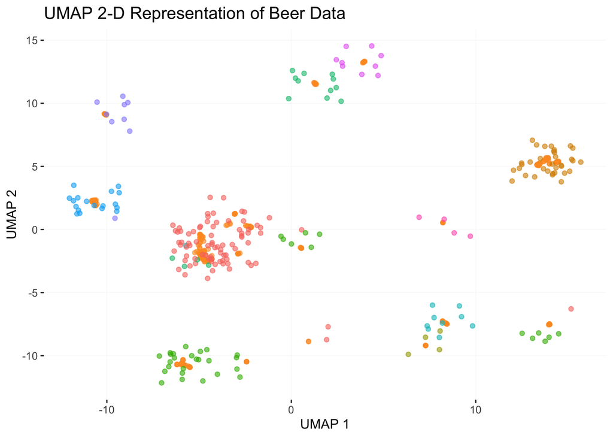

```r
# Plotting UMAP
umap_plotting_data <- cbind(beer_data_with_clusters,umap_output$embedding)
umap_plotting_data <- umap_plotting_data %>% rename(UMAP_X = `1`,UMAP_Y = `2`)
gg_umap <- ggplot(data = umap_plotting_data,aes(x = UMAP_X,
                                                y = UMAP_Y,
                                                colour = Ingr_Cluster,
                                                text = paste0(Brand,"<br>",Brand_Style,"<br>","ABV: ",ABV))) +
  geom_point(colour = "#fe9929",
             alpha = .6) +
  labs(title = "UMAP 2-D Representation of Beer Data",
       x = "UMAP 1",
       y = "UMAP 2") +
  theme(plot.title = element_markdown(size = 14),
        plot.subtitle = element_markdown(size = 10),
        plot.caption = element_markdown(),
        legend.position = "bottom",
        panel.background = element_rect(fill = "white", colour = "white"),
        panel.grid.major = element_line(colour = "#f0f0f0",size = .1)) +
  geom_jitter(width = 1.5, height = 1.5,alpha = .6,
              show.legend = FALSE) #used because some beers are *too* similar and overlap
```

# Nearest Neighbors & Recommendations

As I mentioned earlier, because I have a smaller data set (n = 222), UMAP can extract the exact nearest neighbors. The code below creates a “nearest neighbors” data set, which I’ll use to show beer recommendations based on any given selection.

```r
# Extract Nearest Neigbor Data
beer_nn_data <- cbind(beer_data %>% select("Brand","Brand_Style"),umap_output$nn)
beer_nn_data <- beer_nn_data %>%
  pivot_longer(starts_with("euclidean"),
               names_to = c(".value", "set"),
               names_pattern = "(euclidean\\.[a-z]*\\.)(.)")
names(beer_nn_data) <- c("Brand","Brand_Style","Neighbor_Rk","Neighbor_Idx","Neighbor_Dist")
```

I’ll show two examples. One go-to beer, and one beer that’s not so basic. Here are the top recommendations if you enjoy Miller Lite, but you’re looking to try a different domestic MolsonCoors product.

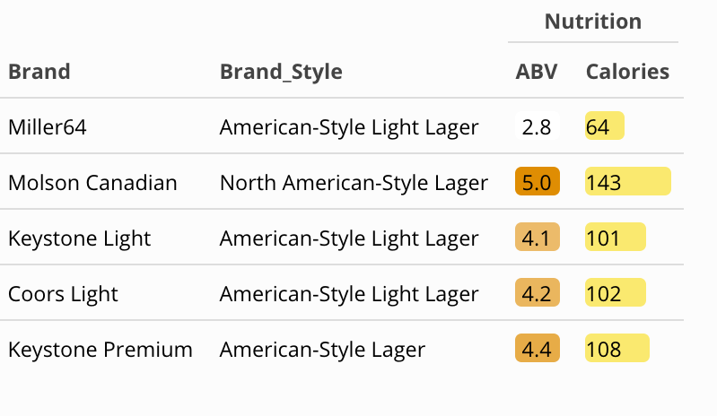

```r
selection <- c("Miller Lite")
idxs <- beer_nn_data %>% filter(Brand %in% selection, Neighbor_Rk <= 5) %>% pull(Neighbor_Idx)

neighbor_points <- beer_full %>%
  filter(Brand != selection) %>%
  slice(idxs) %>%
  select(Brand, Brand_Style, ABV, Calories)

neighbor_points <- neighbor_points %>%
  mutate(ABV = color_tile("white","#df8d03")(ABV),
         Calories = color_bar("#fae96f")(Calories))

kable(neighbor_points, escape = F) %>%
  kable_styling(full_width = FALSE, position = "left",
                bootstrap_options = c("hover")) %>%
  row_spec(1:nrow(neighbor_points), color = "black") %>%
  column_spec(3:4,width = "1cm") %>%
  add_header_above(c(" "= 2, "Nutrition" = 2))
```

The next example will be for Blue Moon Honey Wheat. The recommendations for this one aren’t quite as obvious.

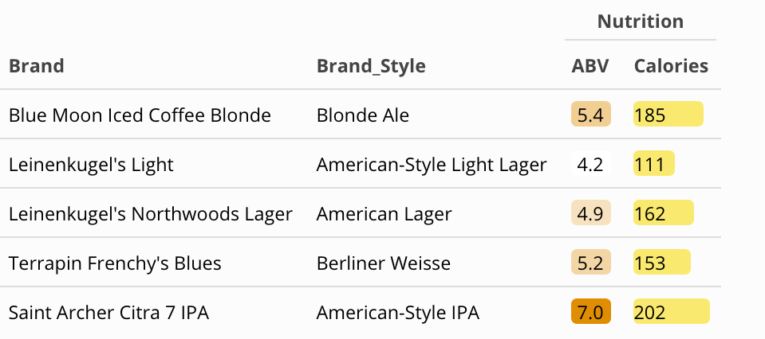

```r
selection <- c("Blue Moon Honey Wheat")
idxs <- beer_nn_data %>% filter(Brand %in% selection, Neighbor_Rk <= 5) %>% pull(Neighbor_Idx)

neighbor_points <- beer_full %>%
  filter(Brand != selection) %>%
  slice(idxs) %>%
  select(Brand, Brand_Style, ABV, Calories)

neighbor_points <- neighbor_points %>%
  mutate(ABV = color_tile("white","#df8d03")(ABV),
         Calories = color_bar("#fae96f")(Calories))

kable(neighbor_points, escape = F) %>%
  kable_styling(full_width = FALSE, position = "left",
                bootstrap_options = c("hover")) %>%
  row_spec(1:nrow(neighbor_points), color = "black") %>%
  column_spec(3:4,width = "1cm") %>%
  add_header_above(c(" "= 2, "Nutrition" = 2))
```

I’ve personally had none of these beers, so I have a few to try out; especially that Blue Moon Iced Coffee Blonde.

# Conclusion

I hope this mini-tutorial was a helpful introduction on how to use clustering and UMAP to build a recommender system. I’d love to expand this to all breweries & beers that have publicly available nutrition information, but that would take quite a bit of research on finding and combining the data. If you are reading this and you know of a large, publicly available “beer-database”, please send the information my way by emailing me at spelkofer24@yahoo.com.

Cheers!

@Spelk24